# Devices_analysis

### Car 5

```python
#Plotting the path of the car.
lat_device = list(data.loc[data.DeviceNumber == 'device_5']['Latitude'])
lon_device = list(data.loc[data.DeviceNumber == 'device_5']['Longitude'])
lat = [lat_device[0]]
lon = [lon_device[0]]
for i in range(1, len(lat_device)):
    if lat_device[i] != lat_device[i-1] or lon_device[i] != lon_device[i-1]:
        lat.append(lat_device[i])
        lon.append(lon_device[i])

cars_map = folium.Map(location=[np.mean(lat), np.mean(lon)], zoom_start=10)
marker_cluster = folium.MarkerCluster().add_to(cars_map)
folium.PolyLine(zip(lat, lon), color="blue", weight=2.5, opacity=1).add_to(cars_map)
folium.LatLngPopup().add_to(cars_map)
cars_map
```

[interactive chart not shown]

This car differs from other cars: it speed is zero for all the day, but it still moves (a little), and it's doors, hood and trunk are opened. The only reason I could think of is that the car is being repaired.

### Car 6

```
Mileage at the beginning of the day: 243 km. Drove today 303 km or increased mileage by 124.69%.
00:00:29 - 07:19:15 Stayed for 7:18:46. Average temperature was 40. Opened: Driver door.
07:19:15 - 08:09:35 Drove for 0:50:20. Traveled 70.0 km, with average speed 101, EngineRPM 1803 and temperature 42.
08:09:35 - 08:18:03 Stayed for 0:08:28. Average temperature was 36. Opened: Driver door.
08:18:03 - 08:32:13 Drove for 0:14:10. Traveled 25.0 km, with average speed 120, EngineRPM 2020 and temperature 37.
08:32:13 - 09:02:06 Stayed for 0:29:53. Average temperature was 39. Opened: Driver door.
09:02:06 - 09:36:08 Drove for 0:34:02. Traveled 22.0 km, with average speed 50, EngineRPM 1422 and temperature 41.
09:36:08 - 10:11:28 Stayed for 0:35:20. Average temperature was 42. Opened: Driver door.
10:11:28 - 11:30:23 Drove for 1:18:55. Traveled 118.0 km, with average speed 101, EngineRPM 1827 and temperature 37.
11:30:23 - 12:25:04 Stayed for 0:54:41. Average temperature was 35. Opened: nothing.
12:25:04 - 12:43:01 Drove for 0:17:57. Traveled 19.0 km, with average speed 74, EngineRPM 1592 and temperature 39.
12:43:01 - 13:59:39 Stayed for 1:16:38. Average temperature was 40. Opened: Driver door, Passenger door.
13:59:39 - 14:09:53 Drove for 0:10:14. Traveled 7.0 km, with average speed 37, EngineRPM 1273 and temperature 42.
14:09:53 - 14:17:17 Stayed for 0:07:24. Average temperature was 38. Opened: Passenger door.
14:17:23 - 14:48:14 Stayed for 0:30:51. Average temperature was 32. Opened: Trunk, Driver door, Passenger door, Left rear door, Right rear door.
14:48:14 - 14:59:22 Drove for 0:11:08. Traveled 6.0 km, with average speed 41, EngineRPM 1439 and temperature 33.
14:59:22 - 15:59:00 Stayed for 0:59:38. Average temperature was 37. Opened: Driver door, Passenger door, Left rear door, Right rear door.
15:59:00 - 16:20:43 Drove for 0:21:43. Traveled 19.0 km, with average speed 59, EngineRPM 1468 and temperature 38.
16:20:43 - 16:57:53 Stayed for 0:37:10. Average temperature was 36. Opened: Driver door, Left rear door, Right rear door.
16:57:53 - 17:15:44 Drove for 0:17:51. Traveled 17.0 km, with average speed 64, EngineRPM 1477 and temperature 37.
17:15:44 - midnight Stayed till the end of the day. Average temperature was 42. Opened: Driver door.
```

[interactive chart not shown]

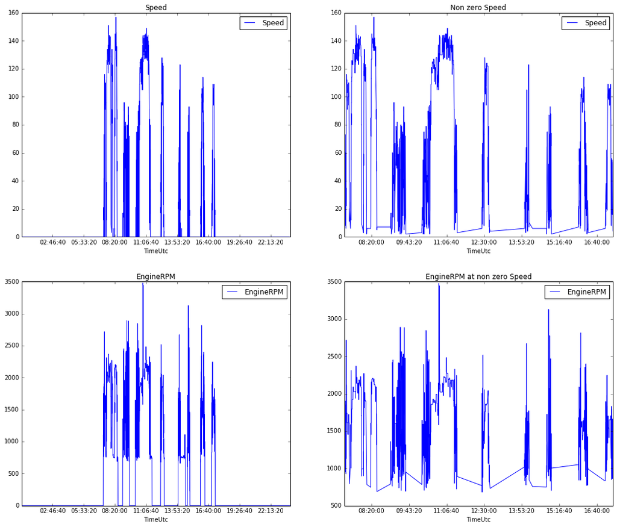

```python
car_data('device_6')
```

The driver left home alone in the morning. He/she drove to Dubai and during the way stopped at Epco Gas Station. In Dubai he/she stopped near a supermarket and medical center. Then he/she drove to Town Centre Jumeirah - a shopping center. After this he/she drove back and parked near a big shopping center. Later he/she returned home. When the car left, there was a passenger. They arrived to a Tim Hortons - multinational fast food restaurant. Then they (and more passengers) drove back home - maybe they were guests. Some time later the car drove to a place at E11 and left passengers from back seats there. And this was the last destination, as the car returned home at ~ 17 hours.

The car drove at high speeds, but mostly within limits. Maybe sometimes the speed was a bit too high between the speed cameras. It seems that the car is quite new and the driver may use it a lot.

The driver shops a lot and drives many people. A social person.

### Car 7

```
Mileage at the beginning of the day: 18 km. Drove today 278 km or increased mileage by 1544.44%.
00:00:41 - 05:14:15 Stayed for 5:13:34. Average temperature was 44. Opened: Trunk, Hood, Driver door, Passenger door, Left rear door, Right rear door.
05:14:15 - 05:20:39 Drove for 0:06:24. Traveled 1.0 km, with average speed 7, EngineRPM 992 and temperature 45.
05:20:39 - 05:33:07 Stayed for 0:12:28. Average temperature was 43. Opened: Driver door.
05:33:07 - 05:35:24 Drove for 0:02:17. Traveled 0.0 km, with average speed 8, EngineRPM 1044 and temperature 42.
05:35:24 - 06:52:10 Stayed for 1:16:46. Average temperature was 44. Opened: Trunk, Hood, Driver door, Passenger door, Left rear door, Right rear door.
06:52:10 - 06:55:51 Drove for 0:03:41. Traveled 1.0 km, with average speed 9, EngineRPM 1017 and temperature 46.
06:55:51 - 08:02:29 Stayed for 1:06:38. Average temperature was 45. Opened: Trunk, Hood, Driver door, Passenger door, Left rear door.
08:02:29 - 08:05:32 Drove for 0:03:03. Traveled 0.0 km, with average speed 5, EngineRPM 1058 and temperature 46.
08:05:32 - 13:01:25 Stayed for 4:55:53. Average temperature was 57. Opened: Driver door.
13:01:25 - 13:01:34 Drove for 0:00:09. Traveled 0.0 km, with average speed 6, EngineRPM 1081 and temperature 56.
13:01:34 - 13:12:22 Stayed for 0:10:48. Average temperature was 55. Opened: Trunk, Driver door, Left rear door.
13:12:22 - 13:13:57 Drove for 0:01:35. Traveled 1.0 km, with average speed 38, EngineRPM 1565 and temperature 54.
13:13:57 - 14:18:28 Stayed for 1:04:31. Average temperature was 52. Opened: Driver door, Passenger door.
14:18:28 - 14:21:28 Drove for 0:03:00. Traveled 2.0 km, with average speed 61, EngineRPM 1558 and temperature 52.
14:21:28 - 14:26:56 Stayed for 0:05:28. Average temperature was 49. Opened: nothing.
14:26:56 - 15:06:13 Drove for 0:39:17. Traveled 54.0 km, with average speed 96, EngineRPM 1700 and temperature 40.
15:06:13 - 16:00:08 Stayed for 0:53:55. Average temperature was 39. Opened: Driver door.
16:00:08 - 16:02:50 Drove for 0:02:42. Traveled 0.0 km, with average speed 11, EngineRPM 1074 and temperature 43.
16:02:50 - 16:07:29 Stayed for 0:04:39. Average temperature was 42. Opened: Trunk, Driver door, Passenger door.
16:07:29 - 18:01:47 Drove for 1:54:18. Traveled 168.0 km, with average speed 99, EngineRPM 1691 and temperature 33.
18:01:47 - 19:03:37 Stayed for 1:01:50. Average temperature was 36. Opened: Trunk, Driver door, Passenger door, Left rear door, Right rear door.
19:03:37 - 19:08:35 Drove for 0:04:58. Traveled 2.0 km, with average speed 18, EngineRPM 1216 and temperature 42.
19:08:35 - 19:12:10 Stayed for 0:03:35. Average temperature was 40. Opened: Driver door.
19:12:10 - 19:16:13 Drove for 0:04:03. Traveled 0.0 km, with average speed 15, EngineRPM 1235 and temperature 39.
19:16:13 - 19:46:03 Stayed for 0:29:50. Average temperature was 34. Opened: Driver door, Passenger door.
19:46:03 - 20:20:22 Drove for 0:34:19. Traveled 47.0 km, with average speed 90, EngineRPM 1702 and temperature 32.
20:20:22 - midnight Stayed till the end of the day. Average temperature was 41. Opened: Driver door.
```

[interactive chart not shown]

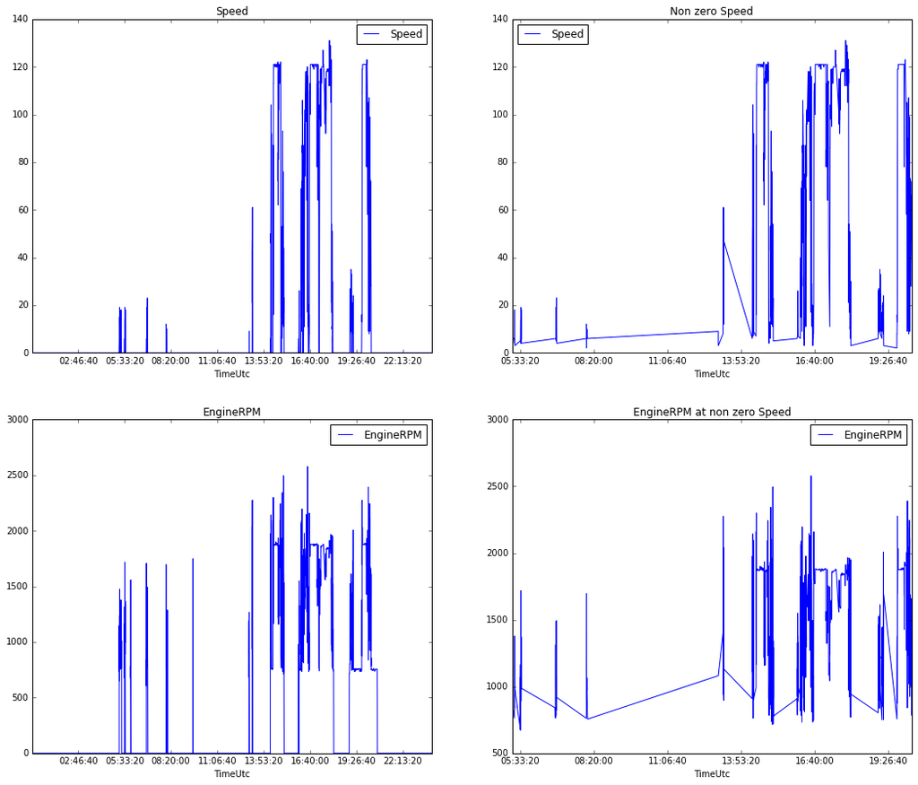

```python
car_data('device_7')
```

A new car (very low mileage). It seems that there were some problems with the car - the hood was opened in the morning and then the car drove to something like a car shop. Probably there the car was repaired. Then there was a stop at a parking... well, not really. The car was taken to the Dubai - it seems the initial repair wasn't successful. Now the things got better - car became able to move and drove to a gas station.

Then they ate at a restaurant and visited another gas station. Interesting point is that only a driver left the car at a long stop near the restaurant. Maybe the passenger was transported by a car company? Anyway he/she left a passenger at E11 and finished the travel in a place different from the initial. Second home?

The car drove somewhere within the speed limits.

So the new car with some technical problems. Maybe changing it is a good idea? By maybe it is normal for a car to visit the car shop during the first days after the purchase. I can't be sure.

### Car 8

```
Mileage at the beginning of the day: 11 km. Drove today 437 km or increased mileage by 3972.73%.
00:00:44 - 05:04:47 Stayed for 5:04:03. Average temperature was 38. Opened: Driver door.
05:04:47 - 05:07:15 Drove for 0:02:28. Traveled 0.0 km, with average speed 12, EngineRPM 1161 and temperature 36.
05:07:15 - 05:43:40 Stayed for 0:36:25. Average temperature was 36. Opened: Driver door, Passenger door.
05:43:40 - 05:46:54 Drove for 0:03:14. Traveled 0.0 km, with average speed 5, EngineRPM 968 and temperature 39.
05:46:54 - 06:13:29 Stayed for 0:26:35. Average temperature was 34. Opened: Driver door.
06:13:34 - 06:24:51 Stayed for 0:11:17. Average temperature was 31. Opened: Trunk, Driver door, Passenger door, Left rear door, Right rear door.
06:24:51 - 06:27:29 Drove for 0:02:38. Traveled 0.0 km, with average speed 3, EngineRPM 931 and temperature 33.
06:27:29 - 08:26:44 Stayed for 1:59:15. Average temperature was 40. Opened: Trunk, Hood, Driver door, Passenger door, Left rear door, Right rear door.
08:26:44 - 08:29:26 Drove for 0:02:42. Traveled 1.0 km, with average speed 18, EngineRPM 1300 and temperature 37.
08:29:26 - 08:36:03 Stayed for 0:06:37. Average temperature was 35. Opened: Driver door.
08:36:03 - 08:45:37 Drove for 0:09:34. Traveled 7.0 km, with average speed 50, EngineRPM 1724 and temperature 33.
08:45:37 - 13:07:34 Stayed for 4:21:57. Average temperature was 46. Opened: Trunk, Driver door, Passenger door, Right rear door.
13:07:34 - 13:14:01 Drove for 0:06:27. Traveled 4.0 km, with average speed 49, EngineRPM 1795 and temperature 47.
13:14:01 - 14:11:37 Stayed for 0:57:36. Average temperature was 44. Opened: Driver door.
14:11:37 - 14:30:33 Drove for 0:18:56. Traveled 17.0 km, with average speed 63, EngineRPM 1651 and temperature 41.
14:30:33 - 14:42:41 Stayed for 0:12:08. Average temperature was 35. Opened: Driver door.
14:42:41 - 15:27:29 Drove for 0:44:48. Traveled 84.0 km, with average speed 132, EngineRPM 2135 and temperature 33.
15:27:29 - 15:31:42 Stayed for 0:04:13. Average temperature was 36. Opened: nothing.
15:31:42 - 16:19:32 Drove for 0:47:50. Traveled 71.0 km, with average speed 121, EngineRPM 2059 and temperature 35.
16:19:32 - 16:46:09 Stayed for 0:26:37. Average temperature was 32. Opened: Trunk, Driver door.
16:46:09 - 17:02:10 Drove for 0:16:01. Traveled 9.0 km, with average speed 58, EngineRPM 1590 and temperature 32.
17:02:10 - 17:11:03 Stayed for 0:08:53. Average temperature was 30. Opened: nothing.
17:11:03 - 17:41:56 Drove for 0:30:53. Traveled 40.0 km, with average speed 101, EngineRPM 1764 and temperature 33.
17:41:56 - 17:50:35 Stayed for 0:08:39. Average temperature was 33. Opened: nothing.
17:50:35 - 18:08:28 Drove for 0:17:53. Traveled 25.0 km, with average speed 104, EngineRPM 1987 and temperature 31.
18:08:28 - 18:11:51 Stayed for 0:03:23. Average temperature was 30. Opened: Trunk, Driver door.
18:11:51 - 18:24:37 Drove for 0:12:46. Traveled 10.0 km, with average speed 58, EngineRPM 1590 and temperature 30.
18:24:37 - 18:38:59 Stayed for 0:14:22. Average temperature was 29. Opened: Driver door.
18:38:59 - 18:52:07 Drove for 0:13:08. Traveled 15.0 km, with average speed 84, EngineRPM 1800 and temperature 30.
18:52:07 - 19:02:57 Stayed for 0:10:50. Average temperature was 29. Opened: nothing.
19:02:57 - 20:46:04 Drove for 1:43:07. Traveled 153.0 km, with average speed 111, EngineRPM 1965 and temperature 30.
20:46:04 - midnight Stayed till the end of the day. Average temperature was 40. Opened: Driver door.
```

[interactive chart not shown]

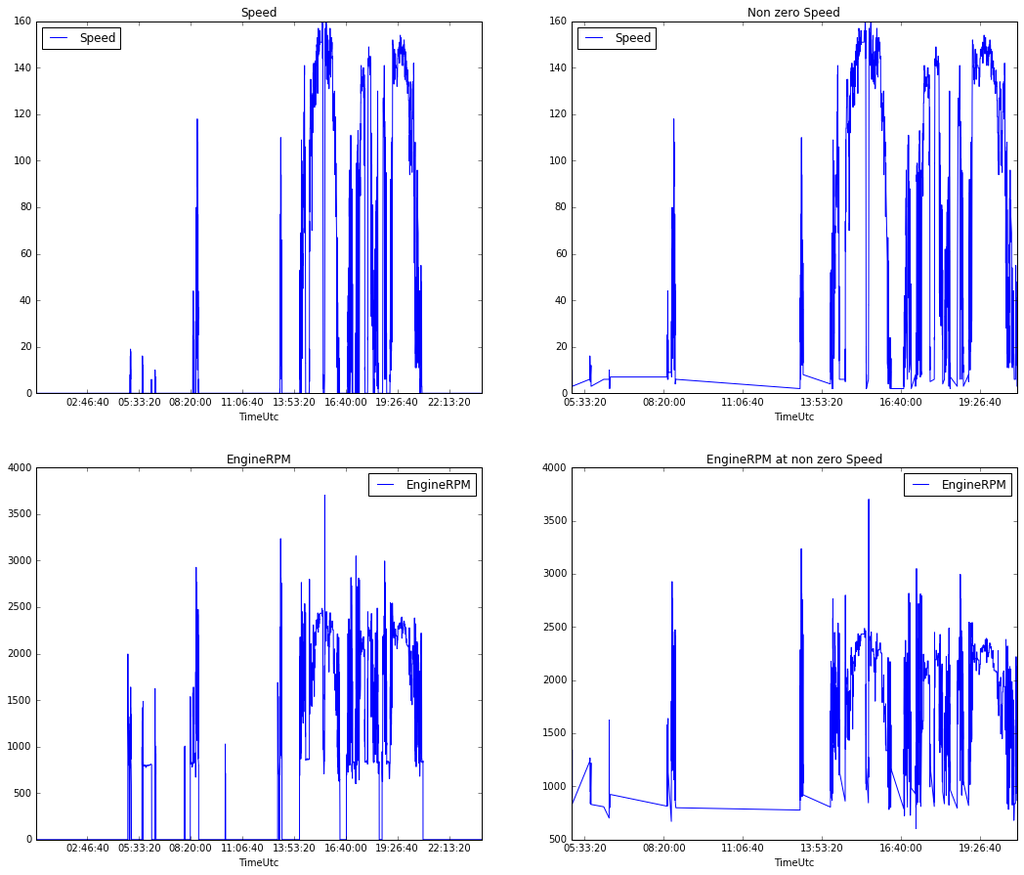

```python
car_data('device_8')
```

It seems that this is also a new car with some technical problems: in the morning the hood was opened and then nearby car center was visited. Or the car simply was in the car center and it was driven to the owner's place later. Another possibility is that the car was bought in the morning, but not sure - it is quite early.

Then the car drove to Abu Dhabi and visited a gas station on the way there. Also a stop was made at two more gas station.

After this the car drove to some place called Village Center, but nobody left the car. Maybe there was a short meeting with someone? And then the car returned to the first city.

Very high speed. A new car. And several visits to gas stations. Not sure what to conclude. Could this be an electrical car? Or maybe it is simply a new car and that's the reason for it's behavior.

### Car 9

```
Mileage at the beginning of the day: 326 km. Drove today 13 km or increased mileage by 3.99%.
00:00:45 - 12:28:30 Stayed for 12:27:45. Average temperature was 44. Opened: Driver door, Left rear door.
12:28:30 - 12:42:21 Drove for 0:13:51. Traveled 6.0 km, with average speed 39, EngineRPM 1520 and temperature 45.
12:42:21 - 13:11:36 Stayed for 0:29:15. Average temperature was 41. Opened: Trunk, Driver door, Left rear door, Right rear door.
13:11:36 - 13:21:54 Drove for 0:10:18. Traveled 7.0 km, with average speed 59, EngineRPM 1810 and temperature 42.
13:21:54 - midnight Stayed till the end of the day. Average temperature was 45. Opened: Trunk, Driver door, Passenger door, Left rear door, Right rear door.
```

[interactive chart not shown]

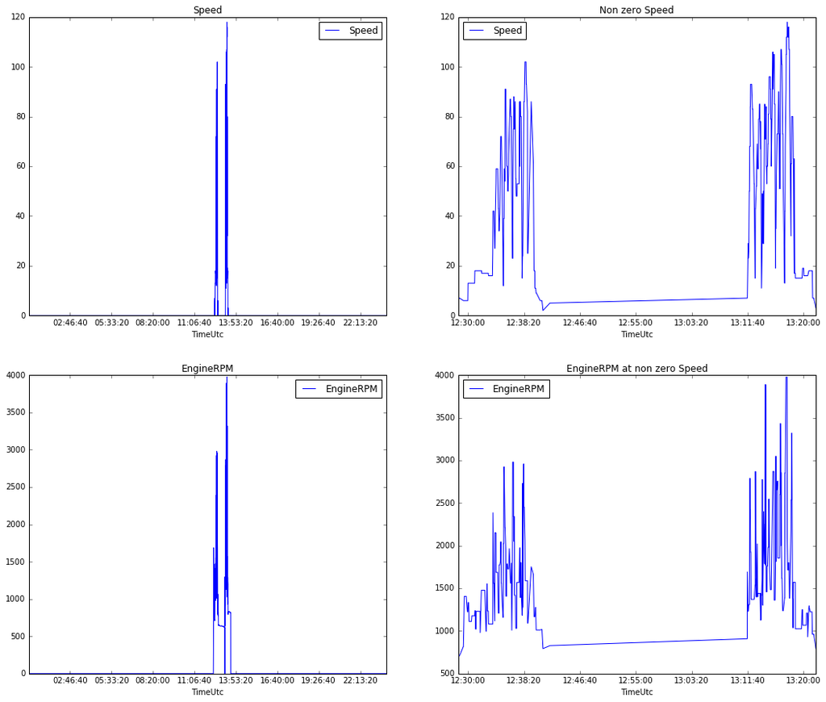

```python
car_data('device_9')
```

Very little data. A family drove the car at midday. They stayed at some place for half an hour and returned home. The car is quite new and is little used today. It seems that the driver likes to drive fast.

### Car 10

```
Mileage at the beginning of the day: 151 km. Drove today 131 km or increased mileage by 86.75%.
00:00:59 - 05:26:08 Stayed for 5:25:09. Average temperature was 44. Opened: Driver door.
05:26:08 - 05:29:18 Drove for 0:03:10. Traveled 1.0 km, with average speed 26, EngineRPM 1216 and temperature 44.
05:29:18 - 05:43:09 Stayed for 0:13:51. Average temperature was 41. Opened: Driver door, Passenger door, Left rear door.
05:43:09 - 05:49:38 Drove for 0:06:29. Traveled 3.0 km, with average speed 34, EngineRPM 1385 and temperature 39.
05:49:38 - 05:53:31 Stayed for 0:03:53. Average temperature was 38. Opened: Driver door.
05:53:31 - 05:56:34 Drove for 0:03:03. Traveled 1.0 km, with average speed 41, EngineRPM 1501 and temperature 38.
05:56:34 - 06:11:15 Stayed for 0:14:41. Average temperature was 37. Opened: Driver door.
06:11:15 - 06:16:26 Drove for 0:05:11. Traveled 4.0 km, with average speed 49, EngineRPM 1317 and temperature 36.
06:16:26 - 06:51:00 Stayed for 0:34:34. Average temperature was 40. Opened: Driver door, Left rear door.
06:51:00 - 06:59:34 Drove for 0:08:34. Traveled 3.0 km, with average speed 40, EngineRPM 1391 and temperature 44.
06:59:34 - 07:12:20 Stayed for 0:12:46. Average temperature was 43. Opened: Driver door, Passenger door.
07:12:20 - 07:32:14 Drove for 0:19:54. Traveled 12.0 km, with average speed 50, EngineRPM 1373 and temperature 41.
07:32:14 - 07:42:29 Stayed for 0:10:15. Average temperature was 40. Opened: Driver door, Passenger door.
07:42:29 - 07:45:38 Drove for 0:03:09. Traveled 2.0 km, with average speed 55, EngineRPM 1400 and temperature 41.
07:45:38 - 07:49:04 Stayed for 0:03:26. Average temperature was 41. Opened: nothing.
07:49:04 - 08:05:01 Drove for 0:15:57. Traveled 5.0 km, with average speed 29, EngineRPM 1273 and temperature 40.
08:05:01 - 08:23:50 Stayed for 0:18:49. Average temperature was 41. Opened: Driver door, Left rear door, Right rear door.
08:23:50 - 08:26:54 Drove for 0:03:04. Traveled 0.0 km, with average speed 25, EngineRPM 1327 and temperature 43.
08:26:54 - 08:45:25 Stayed for 0:18:31. Average temperature was 45. Opened: Driver door, Passenger door.
08:45:25 - 08:51:56 Drove for 0:06:31. Traveled 0.0 km, with average speed 9, EngineRPM 852 and temperature 46.
08:51:56 - 08:58:52 Stayed for 0:06:56. Average temperature was 45. Opened: nothing.
08:58:52 - 09:01:51 Drove for 0:02:59. Traveled 2.0 km, with average speed 34, EngineRPM 1334 and temperature 44.
09:01:51 - 12:30:44 Stayed for 3:28:53. Average temperature was 50. Opened: Trunk, Driver door, Passenger door, Left rear door.
12:30:44 - 12:42:56 Drove for 0:12:12. Traveled 6.0 km, with average speed 39, EngineRPM 1305 and temperature 46.
12:42:56 - 12:52:37 Stayed for 0:09:41. Average temperature was 42. Opened: Driver door, Passenger door, Right rear door.
12:52:37 - 13:35:49 Drove for 0:43:12. Traveled 28.0 km, with average speed 47, EngineRPM 1282 and temperature 38.
13:35:49 - 13:39:50 Stayed for 0:04:01. Average temperature was 36. Opened: Passenger door, Left rear door, Right rear door.
13:39:50 - 13:47:50 Drove for 0:08:00. Traveled 1.0 km, with average speed 18, EngineRPM 1133 and temperature 36.
13:47:50 - 13:57:19 Stayed for 0:09:29. Average temperature was 36. Opened: Driver door, Left rear door.
13:57:19 - 14:00:30 Drove for 0:03:11. Traveled 0.0 km, with average speed 21, EngineRPM 1182 and temperature 37.
14:00:30 - 14:21:47 Stayed for 0:21:17. Average temperature was 39. Opened: Driver door.
14:21:47 - 14:27:00 Drove for 0:05:13. Traveled 2.0 km, with average speed 30, EngineRPM 1280 and temperature 41.
14:27:00 - 14:51:19 Stayed for 0:24:19. Average temperature was 42. Opened: Driver door, Left rear door.
14:51:19 - 14:53:30 Drove for 0:02:11. Traveled 0.0 km, with average speed 29, EngineRPM 1236 and temperature 43.
14:53:30 - 14:57:27 Stayed for 0:03:57. Average temperature was 43. Opened: nothing.
14:57:27 - 15:31:02 Drove for 0:33:35. Traveled 9.0 km, with average speed 22, EngineRPM 1093 and temperature 40.
15:31:02 - 15:48:56 Stayed for 0:17:54. Average temperature was 39. Opened: Driver door, Left rear door.
15:48:56 - 15:53:09 Drove for 0:04:13. Traveled 2.0 km, with average speed 35, EngineRPM 1313 and temperature 41.
15:53:09 - 16:02:53 Stayed for 0:09:44. Average temperature was 41. Opened: Driver door, Passenger door.
16:02:53 - 16:12:50 Drove for 0:09:57. Traveled 3.0 km, with average speed 24, EngineRPM 1212 and temperature 42.
16:12:50 - 16:21:43 Stayed for 0:08:53. Average temperature was 40. Opened: nothing.
16:21:43 - 16:53:16 Drove for 0:31:33. Traveled 19.0 km, with average speed 47, EngineRPM 1328 and temperature 39.
16:53:16 - 16:58:49 Stayed for 0:05:33. Average temperature was 38. Opened: Left rear door.
16:58:49 - 17:47:47 Drove for 0:48:58. Traveled 18.0 km, with average speed 28, EngineRPM 1190 and temperature 36.
17:47:47 - 17:56:35 Stayed for 0:08:48. Average temperature was 36. Opened: nothing.
17:56:35 - 18:03:07 Drove for 0:06:32. Traveled 1.0 km, with average speed 23, EngineRPM 1145 and temperature 36.
18:03:07 - 18:07:20 Stayed for 0:04:13. Average temperature was 37. Opened: Passenger door, Right rear door.
18:07:20 - 18:12:59 Drove for 0:05:39. Traveled 1.0 km, with average speed 22, EngineRPM 1124 and temperature 38.
18:12:59 - midnight Stayed till the end of the day. Average temperature was 47. Opened: Driver door, Passenger door, Left rear door, Right rear door.
```

[interactive chart not shown]

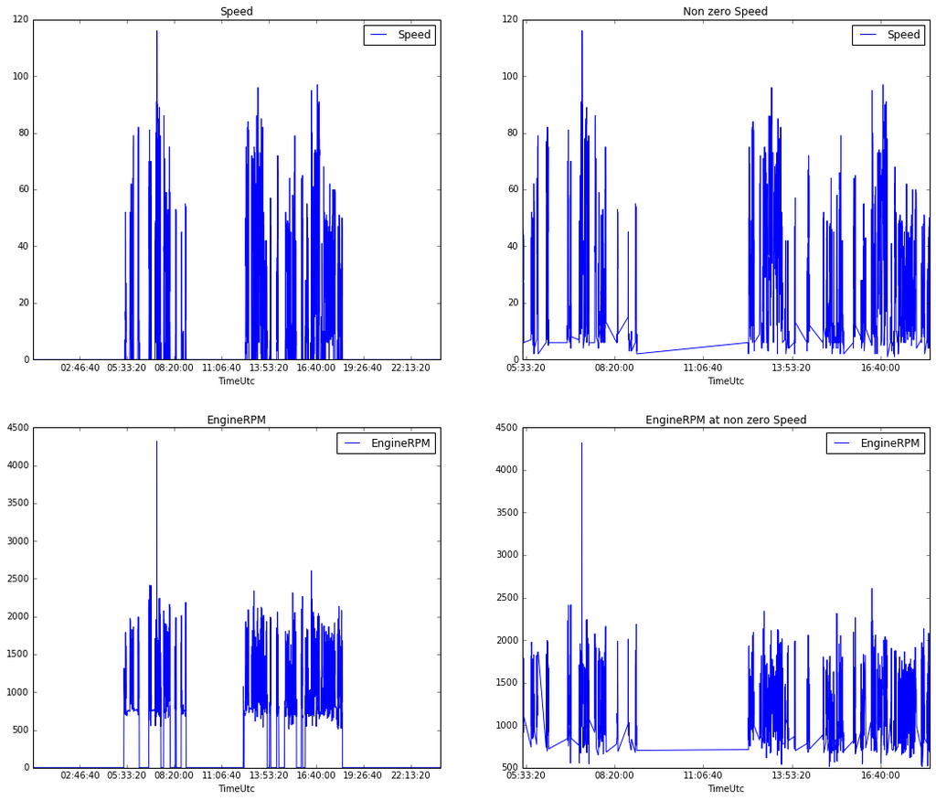

```python
car_data('device_10')
```

This car drives actively. It drives around a town and makes stops at various places. Most of the time the speed is normal, except one time period with a high speed. The key is in the starting and ending point, which was also visited three times during the day: it is near Fujairah Police Station. So I conclude that this is a police car.

## Data usage

Insurance companies use telematic data a lot. Usage-based insurance provides lower costs for drivers and lower risks for insurance companies. Telematic data can uncover frauds (nonaccidental crashes) or find the real reason behind the crashes.

Car companies also can gain profit from telematic data. If the car has high mileage, they can offer check-ups for the driver, for example. They may find problems in the car remotely and offer the repair before something breaks. Or maybe based on the information about how the cars are used, the companies will make modifications in future cars.

One more possibility is combining telematic data with smart houses. For example, if the car arrives at home, the garade doors could open automatically.

Another idea is using telematic data for advertising. If the driver often visits supermarkets, products could be offered. If the driver drives to cafes, cafes may be advertised and so on.